# Netzwerkanalyse

### Vorgeschlagene Videos

Um die vorgeschlagenen Videos als Netwzerk darzustellen, können wir ähnlich vorgehen. Zunächst erstellen wir ein Netzwerk zwischen den Videos, bei dem eine Verbindung darstellt, um ein Video von einem anderen vorgeschlagen wird - oder auch nicht. Da wir in diesem Netzwerk nur den Knotentyp “Video” haben, handelt es sich, im Gegensatz zu dem Video-Kommentar-Graphen oben, um ein **monopartites Netzwerk**. Auch hier wählen wir zunächst die relevanten Variablen und deren Reihenfolge mit `select()` aus, bevor wir mit `as_tbl_graph()` einen Netzwerkgraphen bilden. Hier also einen **gerichteten** Graphen von Video ID zur ID des vorgeschlagenen Videos.

```r
related_graph <- related_videos_january %>%
  select(video_id, rel_video_id) %>%
  as_tbl_graph(directed = TRUE)
```

Erneut können wir unseren Graphen einfach mit `ggraph()` visualisieren:

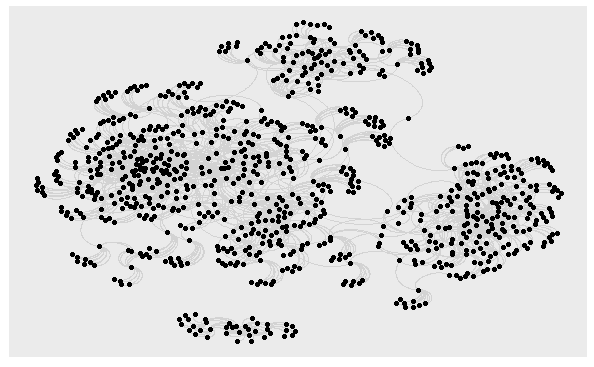

```r
ggraph(related_graph, layout = "fr") +
  geom_edge_arc(color = "lightgrey") +
  geom_node_point()
```

Außerdem möchten wir wissen, welche Knoten - also welche Videos - die höchste **Betweenness** aufweisen. Diese berechnet, wieviele kürzeste Pfade von einem beliebigen Knoten zu einem beliebigen anderen Knoten führen. Je mehr kürzeste Pfade durch einen Knoten führen, desto *zentraler* ist er im Netzwerk. Mit anderen Worten: An einem Knoten mit hoher **Betweenness** gibt es quasi kein Vorbeikommen. Wenn wir uns von einem Knoten zu einem anderen bewegen - etwa, wenn wir uns durch die vorgeschlagenen Videos klicken - werden wir früher oder später wahrscheinlich auf einen solchen Knoten stoßen.

Ähnlich wie oben den Degree, können wir *tidygraph* verwenden, um die betweenness zu berechnen. Diesmal filtern wir jedoch nicht, da wir unser Netzwerk nicht verkleinern möchten.

```r
related_graph <- related_graph %>%
  activate(nodes) %>%
  mutate(betweenness = centrality_betweenness())
```

Nun können wir uns die Videos mit der höchsten Betweenness anzeigen lassen. Um den Titel des Videos zu erhalten, können wir erneut `join_by()` verwenden, um in aus unserem ursprünglichen Datensatz zu ziehen. Zunächst wandeln wir mittels `activate()` und `as_tibble()` jedoch den Graphen in eine Tibble um. Für den join benennen wir zunächt den Namen wieder in ID um und wählen aus unserem ursprünglichen Datensatz nur jene Variablen aus, die wir auch brauchen - nämlich ID und Titel des Videos sowie den Namen das Kanals, der das Video hochgeladen hat. Schlussendlich können wir noch `arrange()` verwenden, um den Datensatz mittels `desc()` nach absteigender Betweenness zu sortieren. So sehen wir schneller, welche Videos relevant sind.

```r
related_graph %>%
  activate(nodes) %>%
  as_tibble() %>%
  rename(video_id = name) %>%
  left_join(related_videos_january %>% select(video_id, title, channelTitle),
            by = "video_id") %>%
  arrange(desc(betweenness))
```

| video_id | betweenness | title | channelTitle |
| --- | --- | --- | --- |
| UxDcyCQj2fY | 707.450000 | Kandidatur Lucia Puttrich MdL | CDU |
| UxDcyCQj2fY | 707.450000 | Hazel Brugger beim CDU-Parteitag - heute-show vom 09.12.2016 \| ZDF | ZDF heute-show |
| UxDcyCQj2fY | 707.450000 | Nur kritiklose Abnicker! Ralf Kabelka auf dem CDU-Parteitag \| heute-show vom 12.12.2014 | ZDF heute-show |
| UxDcyCQj2fY | 707.450000 | Kandidatur Dr. Bernd Althusmann MdL | CDU |
| UxDcyCQj2fY | 707.450000 | Radikaler Neuanfang: Wohin steuert die CDU? - MONITOR | Monitor |
| UxDcyCQj2fY | 707.450000 | Kandidatur Dr. Bastian Schneider | CDU |
| UxDcyCQj2fY | 707.450000 | Holt die CSU weniger als fünf Prozent? Fabian Köster beim Parteitag \| heute-show vom 17.09.2021 | ZDF heute-show |
| UxDcyCQj2fY | 707.450000 | Berufspolitiker im Landtag: So viel Geld bekommt ein Abgeordneter in Bayern \| Lohnt sich das \| BR | Lohnt sich das? |
| UxDcyCQj2fY | 707.450000 | Das Wahlprogramm von CDU/ CSU (Union) erklärt \| Bundestagswahl 2021 | MrWissen2go |
| UxDcyCQj2fY | 707.450000 | JULIA KLÖCKNER: Robert Habeck? Und dann kritisiert die CDU-Frau den Minister scharf I WELT Interview | WELT Nachrichtensender |

[output cut: 990 more lines]

Schlussendlich können wir auch diesen Graphen noch eimal hübscher darstellen. Dafür verwenden wir wieder die Parteifarben, wobei wir die Partei analog zum Vorgehen oben zuerst als Knotenattribut anbringen müssen.

```r
related_graph <- related_graph %>%
  left_join(party_videos_january %>% select(contentDetails.videoId, party_label) %>%
              rename(name = contentDetails.videoId),
            by = "name")
```

Statt dem Degree verwenden wir diesmal jedoch die Betweenness, um die Größe der Knoten festzulegen.

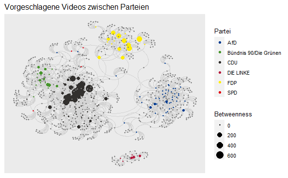

```r
ggraph(related_graph, layout = "fr") +
  geom_edge_arc(color = "lightgrey") +
  geom_node_point(aes(color = party_label, size = betweenness)) +
  scale_color_manual(values = colors) +
  labs(color = "Partei", size = "Betweenness",
       title = "Vorgeschlagene Videos zwischen Parteien")
```